# Homework I

王苡蓁

2019/3/14

# Problem 1

### 1. 請計算每位選手的生涯打擊資料。哪位選手被三振(SO)的次數最多?被三振了幾次? 在出場數(G)低於1000 場的選手中，哪位選手的全壘打數(HR)最多?共打了幾支全壘打?

> Q1:哪位選手被三振(SO)的次數最多?被三振了幾次?

```r
#1-1-Q1計算過程

library(Lahman)
data("Batting")
data("Master")

M1<-select(Master,playerID,nameFirst,nameLast)
B1<-select(Batting,playerID,SO,HR,G)

P1<-merge(M1, B1, by="playerID")

most<-select(P1,playerID,nameFirst,nameLast,SO)%>%arrange(desc(SO))
head(most)
```

```
   playerID nameFirst nameLast  SO
1 reynoma01      Mark Reynolds 223
2  dunnad01      Adam     Dunn 222
3 davisch02     Chris    Davis 219
4 cartech02     Chris   Carter 212
5 reynoma01      Mark Reynolds 211
6 davisch02     Chris    Davis 208
```

> A1:Mark Reynolds被三振(SO)的次數最多，一共被三振（SO）223次

> Q2:在出場數(G)低於 1000 場的選手中，哪位選手的全壘打數(HR)最多? 共打了幾支全壘打?

```r
#1-1-Q2計算過程

least<-select(P1,playerID,nameFirst,nameLast,G,HR)%>% filter(G<1000) %>%arrange(desc(HR))
head(least)
```

```
   playerID nameFirst nameLast   G HR
1 bondsba01     Barry    Bonds 153 73
2 mcgwima01      Mark  McGwire 155 70
3  sosasa01     Sammy     Sosa 159 66
4 mcgwima01      Mark  McGwire 153 65
5  sosasa01     Sammy     Sosa 160 64
6  sosasa01     Sammy     Sosa 162 63
```

> A2:Barry Bonds的全壘打數(HR)最多，共打了73支

### 2.哪位選手其第一次出場比賽(debut)與最後一次出場比賽(finalGame)的間隔時間最久?共隔了幾天?

```r
#1-2計算過程

library(Lahman)
data("Master")

L1<-select(Master,playerID,nameFirst,nameLast,debut,finalGame) %>%na.omit()

da<-L1 %>%select(playerID,nameFirst,nameLast ) %>%mutate(as.Date(L1$finalGame)-as.Date(L1$debut))%>%arrange(desc(as.Date(L1$finalGame) - as.Date(L1$debut)))

head(da)
```

```
   playerID nameFirst nameLast as.Date(L1$finalGame) - as.Date(L1$debut)
1 altroni01      Nick  Altrock                                12862 days
2 orourji01       Jim O'Rourke                                11836 days
3 minosmi01    Minnie   Minoso                                11492 days
4 olearch01   Charley  O'Leary                                11126 days
5 lathaar01     Arlie   Latham                                10678 days
6 mcguide01    Deacon  McGuire                                10192 days
```

> A:Nick Altrock第一次出場比賽(debut)與最後一次出場比賽(finalGame)的間隔時間最久，共隔了12862天

### 3.請計算2015年每個球隊的平均薪資，以及2014年每個球隊的打擊資料(加總)，並將兩組資料根據 teamID 合併。

> Q1.計算2015年每個球隊的平均薪資：

```r
#1-3-Q1計算過程

library(Lahman)
data("AllstarFull")
data("Salaries")

y<-filter(Salaries,yearID==2015)%>% select(teamID,salary)%>%group_by(teamID) %>%summarise(salary_=mean(salary))

y
```

```
# A tibble: 30 x 2
   teamID  salary_
   <fct>     <dbl>
 1 ARI    2132207.
 2 ATL    2990885.
 3 BAL    4108744.
 4 BOS    5659481.
 5 CHA    4161989.
 6 CHN    4138547.
 7 CIN    4187862.
 8 CLE    3022888.
 9 COL    3827544
10 DET    6891390
# … with 20 more rows
```

> Q2.22014年每個球隊的打擊資料(加總)：

```r
#1-3-Q2計算過程

data("Batting")

yy<-filter(Batting,yearID==2014)%>% select(-playerID,-yearID,-stint,-lgID) %>% group_by(teamID) %>%summarise_all(.funs = funs(sum))

yy
```

```
# A tibble: 30 x 18
   teamID     G    AB     R     H   X2B   X3B    HR   RBI    SB    CS    BB
   <fct>  <int> <int> <int> <int> <int> <int> <int> <int> <int> <int> <int>
 1 ARI     2274  5552   615  1379   259    47   118   573    86    33   398
 2 ATL     2252  5468   573  1316   240    22   123   545    95    33   472
 3 BAL     2294  5596   705  1434   264    16   211   681    44    20   401
 4 BOS     2283  5551   634  1355   282    20   123   601    63    25   535
 5 CHA     2285  5543   660  1400   279    32   155   625    85    36   417
 6 CHN     2358  5508   614  1315   270    31   157   590    65    40   442
 7 CIN     2213  5395   595  1282   254    20   131   562   122    52   415
 8 CLE     2391  5575   669  1411   284    23   142   644   104    27   504
 9 COL     2387  5612   755  1551   307    41   186   721    85    48   397
10 DET     2330  5630   757  1557   325    26   155   731   106    41   443
# … with 20 more rows, and 6 more variables: SO <int>, IBB <int>,
#   HBP <int>, SH <int>, SF <int>, GIDP <int>
```

> Q3.2015年每個球隊的平均薪資，以及2014年每個球隊的打擊資料(加總)，並將兩組資料根據teamID 合併：

```r
#1-3-Q3計算過程

library(dplyr)
y2<-merge(y,yy,by="teamID") %>% arrange(desc(salary_))
y3<-inner_join(y,yy,by="teamID") %>% arrange(desc(salary_))

head(y3)
```

```
# A tibble: 6 x 19
  teamID salary_     G    AB     R     H   X2B   X3B    HR   RBI    SB
  <chr>    <dbl> <int> <int> <int> <int> <int> <int> <int> <int> <int>
1 LAN     7.44e6  2364  5560   718  1476   302    38   134   686   138
2 NYA     7.34e6  2288  5497   633  1349   247    26   147   591   112
3 DET     6.89e6  2330  5630   757  1557   325    26   155   731   106
4 SFN     6.10e6  2353  5523   665  1407   257    42   132   636    56
5 BOS     5.66e6  2283  5551   634  1355   282    20   123   601    63
6 WAS     5.37e6  2265  5542   686  1403   265    27   152   635   101
# … with 8 more variables: CS <int>, BB <int>, SO <int>, IBB <int>,
#   HBP <int>, SH <int>, SF <int>, GIDP <int>
```

### 4.根據 3 所得到的資料，使用ggpairs繪製各球隊平均薪資(salary_)與安打數(H)、全壘打數(H)、打點數(RBI)、盜壘數(SB)、三振次數(SO)總數的散布圖。

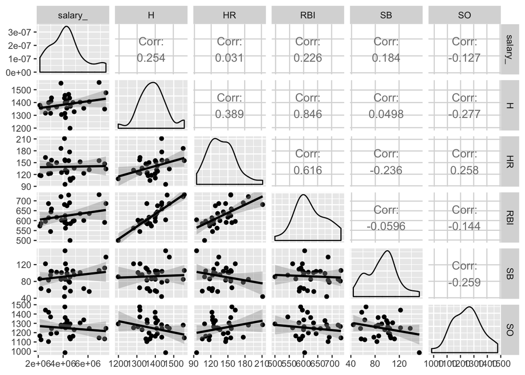

```r
#1-4計算過程

y2 %>% ggpairs(columns = c("salary_", "H", "HR", "RBI", "SB", "SO"), lower = list(continuous = "smooth"))
```

# Problem2

1. Please predict salary by H and show the analysis result.
2. Please predict salary by the z-score of H and show the analysis result.
3. Please compare the values of slope and R2 in these two analyses.

### 1. Please predict salary by H and show the analysis result.

```r
#2-1計算過程

library(magrittr)
library(GGally)
library(ggplot2)
library(Lahman)
library(dplyr)
tbl_Salaries <- tbl_df(Salaries)

tbl_s <- tbl_Salaries %>% filter(yearID == 2015) %>% select(-yearID) %>% mutate(salary = salary/10000)

tbl_Batting <- tbl_df(Batting)

tbl_b <- tbl_Batting %>% filter(yearID == 2014) %>%select(-yearID, -stint, -teamID, -lgID) %>% group_by(playerID) %>% summarise_all(.funs = funs(sum))

tbl_baseball <- inner_join(tbl_s, tbl_b, by = "playerID")  %>% select(AB, H, HR, SB, SO, salary)

lm_fit <- tbl_baseball %>% lm(salary ~ H, data = .)

#Analysis Result
summary(lm_fit)
```

```
Call:
lm(formula = salary ~ H, data = .)

Residuals:
   Min     1Q Median     3Q    Max
-764.9 -279.2 -228.2  119.0 2928.5

Coefficients:
            Estimate Std. Error t value Pr(>|t|)
(Intercept) 295.0029    23.8938  12.346   <2e-16 ***
H             3.0508     0.3225   9.459   <2e-16 ***
---
Signif. codes:  0 '***' 0.001 '**' 0.01 '*' 0.05 '.' 0.1 ' ' 1

Residual standard error: 524.5 on 790 degrees of freedom
Multiple R-squared:  0.1017,    Adjusted R-squared:  0.1006
F-statistic: 89.48 on 1 and 790 DF,  p-value: < 2.2e-16
```

> Salary Predicted by H 模型:y=295.0029+3.0508x

### 2. Please predict salary by the z-score of H and show the analysis result.

```r
#2-2計算過程
Hmean<- mean(tbl_baseball$H)
Hsd<-sd(tbl_baseball$H)

H_z_score<-(tbl_baseball$H-Hmean)/Hsd

tbl_baseball_z <-tbl_baseball%>% select(-H)%>% mutate(H_z_score)

lm_fit_z <- tbl_baseball_z %>% lm(salary ~ H_z_score, data = .)

#Analysis Result
summary(lm_fit_z)
```

```
Call:
lm(formula = salary ~ H_z_score, data = .)

Residuals:
   Min     1Q Median     3Q    Max
-764.9 -279.2 -228.2  119.0 2928.5

Coefficients:
            Estimate Std. Error t value Pr(>|t|)
(Intercept)   436.44      18.64  23.417   <2e-16 ***
H_z_score     176.41      18.65   9.459   <2e-16 ***
---
Signif. codes:  0 '***' 0.001 '**' 0.01 '*' 0.05 '.' 0.1 ' ' 1

Residual standard error: 524.5 on 790 degrees of freedom
Multiple R-squared:  0.1017,    Adjusted R-squared:  0.1006
F-statistic: 89.48 on 1 and 790 DF,  p-value: < 2.2e-16
```

> Salary predicted by z-score of H 預測模型:y=436.44+176.41x

### 3. Please compare the values of slope and R-squared in these two analyses.

| Compare | Slope | R-squared |
| --- | --- | --- |
| H | 3.0508 | 0.1017 |
| z-score of H | 176.4100 | 0.1017 |

# Problem 3

### 1. What are the values of x1 and x2 for the subjects belonging to category A, B, and C,otherwise respectively.

```r
#3-1計算過程
c<-c("A","B","C")
x<-c(1,0,0)
y<-c(0,1,0)

theDF <- data.frame(caregory = c, x1 = x, x2=y )
```

> Values of Dummy Variables

```
  caregory x1 x2
1        A  1  0
2        B  0  1
3        C  0  0
```

### 2. Consider the regression function f(x1,x2)=β0 +β1x1 +β2x2. Find the corresponding values of f(x1,x2) in terms of β0, β1, and β2 for the subjects belonging to category A, B, and C, respectively.

> A : (1,0) = β0 +β1x1 +β2x0 = β0 +β1  
> B : (0,1) = β0 +β1x0 +β2x1 = β0 +β2  
> C : (0,0) = β0 +β1x0 +β2x0 = β0

# Problem 4

### 1. Please predict both salary and HR by using H and then calculate the corresponding residuals e_salary and e_HR.

```r
#4-1計算過程
tbl_Salaries <- tbl_df(Salaries)

tbl_s <- tbl_Salaries %>% filter(yearID == 2015) %>% select(-yearID) %>% mutate(salary = salary/10000)

tbl_Batting <- tbl_df(Batting)

tbl_Batting %>% filter(yearID == 2014) %>% select(-yearID, -stint, -teamID, -lgID)
```

```
# A tibble: 1,435 x 18
   playerID     G    AB     R     H   X2B   X3B    HR   RBI    SB    CS
   <chr>    <int> <int> <int> <int> <int> <int> <int> <int> <int> <int>
 1 abadfe01    69     0     0     0     0     0     0     0     0     0
 2 abreubo…    78   133    12    33     9     0     1    14     1     0
 3 abreujo…   145   556    80   176    35     2    36   107     3     1
 4 abreuto…     3     4     0     0     0     0     0     0     0     0
 5 aceveal…    10     0     0     0     0     0     0     0     0     0
 6 achteaj…     7     0     0     0     0     0     0     0     0     0
 7 ackledu…   143   502    64   123    27     4    14    65     8     4
 8 adamecr…     7    15     1     1     0     0     0     0     0     0
 9 adamsau…     6     0     0     0     0     0     0     0     0     0
10 adamsla…     6     3     1     0     0     0     0     0     0     0
# … with 1,425 more rows, and 7 more variables: BB <int>, SO <int>,
#   IBB <int>, HBP <int>, SH <int>, SF <int>, GIDP <int>
```

```r
tbl_b <- tbl_Batting %>% filter(yearID == 2014) %>%select(-yearID, -stint, -teamID, -lgID) %>% group_by(playerID) %>% summarise_all(.funs = funs(sum))

tbl_baseball <- inner_join(tbl_s, tbl_b, by = "playerID")  %>% select(AB, H, HR, SB, SO, salary)
```

> Q1.Predict salary by H

```r
#4-1-Q1計算過程
lm_fit <- tbl_baseball %>% lm(salary ~ H, data = .)

#result
summary(lm_fit)
```

```
Call:
lm(formula = salary ~ H, data = .)

Residuals:
   Min     1Q Median     3Q    Max
-764.9 -279.2 -228.2  119.0 2928.5

Coefficients:
            Estimate Std. Error t value Pr(>|t|)
(Intercept) 295.0029    23.8938  12.346   <2e-16 ***
H             3.0508     0.3225   9.459   <2e-16 ***
---
Signif. codes:  0 '***' 0.001 '**' 0.01 '*' 0.05 '.' 0.1 ' ' 1

Residual standard error: 524.5 on 790 degrees of freedom
Multiple R-squared:  0.1017,    Adjusted R-squared:  0.1006
F-statistic: 89.48 on 1 and 790 DF,  p-value: < 2.2e-16
```

> salary by H預測模型：y=295.0029+3.0508x

> Q2.Residual standard error of H

```r
#4-1-Q2計算過程
lm_fit %>% residuals() %>% str()
```

```
 Named num [1:792] -287 -247 -247 -173 -243 ...
 - attr(*, "names")= chr [1:792] "1" "2" "3" "4" ...
```

```r
e_salary<- lm_fit %>% residuals()
```

> Q3.Predict HR by H

```r
#4-1-Q3計算過程
lm_fit <- tbl_baseball %>% lm(HR~ H, data = .)

#results
summary(lm_fit)
```

```
Call:
lm(formula = HR ~ H, data = .)

Residuals:
     Min       1Q   Median       3Q      Max
-17.0725  -0.8368   0.1011   0.1011  25.1176

Coefficients:
             Estimate Std. Error t value Pr(>|t|)
(Intercept) -0.101085   0.207939  -0.486    0.627
H            0.104204   0.002807  37.127   <2e-16 ***
---
Signif. codes:  0 '***' 0.001 '**' 0.01 '*' 0.05 '.' 0.1 ' ' 1

Residual standard error: 4.565 on 790 degrees of freedom
Multiple R-squared:  0.6357,    Adjusted R-squared:  0.6352
F-statistic:  1378 on 1 and 790 DF,  p-value: < 2.2e-16
```

> HR預測模型：y=-0.101085+0.104204x

> Q4.Residual standard error of HR

```r
#4-1-Q4計算過程
lm_fit %>% residuals() %>% str()
```

```
 Named num [1:792] -0.35777 -0.00312 -0.00312 -0.52414 0.10108 ...
 - attr(*, "names")= chr [1:792] "1" "2" "3" "4" ...
```

```r
e_HR<- lm_fit %>% residuals()
```

### 2. Use e_HR to predict e_salary and report the slope estimate.

```r
#4-2計算過程
tbl_Salaries <- tbl_df(Salaries)

tbl_s <- tbl_Salaries %>% filter(yearID == 2015) %>% select(-yearID) %>% mutate(salary = salary/10000)

tbl_Batting <- tbl_df(Batting)

tbl_Batting %>% filter(yearID == 2014) %>% select(-yearID, -stint, -teamID, -lgID)
```

```
# A tibble: 1,435 x 18
   playerID     G    AB     R     H   X2B   X3B    HR   RBI    SB    CS
   <chr>    <int> <int> <int> <int> <int> <int> <int> <int> <int> <int>
 1 abadfe01    69     0     0     0     0     0     0     0     0     0
 2 abreubo…    78   133    12    33     9     0     1    14     1     0
 3 abreujo…   145   556    80   176    35     2    36   107     3     1
 4 abreuto…     3     4     0     0     0     0     0     0     0     0
 5 aceveal…    10     0     0     0     0     0     0     0     0     0
 6 achteaj…     7     0     0     0     0     0     0     0     0     0
 7 ackledu…   143   502    64   123    27     4    14    65     8     4
 8 adamecr…     7    15     1     1     0     0     0     0     0     0
 9 adamsau…     6     0     0     0     0     0     0     0     0     0
10 adamsla…     6     3     1     0     0     0     0     0     0     0
# … with 1,425 more rows, and 7 more variables: BB <int>, SO <int>,
#   IBB <int>, HBP <int>, SH <int>, SF <int>, GIDP <int>
```

```r
tbl_b <- tbl_Batting %>% filter(yearID == 2014) %>%select(-yearID, -stint, -teamID, -lgID) %>% group_by(playerID) %>% summarise_all(.funs = funs(sum))

tbl_baseball_e <- inner_join(tbl_s, tbl_b, by = "playerID")  %>% select(AB, H, SB, SO) %>%mutate(e_HR) %>%mutate(e_salary)

lm_fit <- tbl_baseball_e %>% lm(e_salary~ e_HR, data = .)
```

> Use e_HR to predict e_salary

```r
summary(lm_fit)
```

```
Call:
lm(formula = e_salary ~ e_HR, data = .)

Residuals:
   Min     1Q Median     3Q    Max
-805.1 -272.7 -222.8  129.2 2943.1

Coefficients:
              Estimate Std. Error t value Pr(>|t|)
(Intercept) -2.450e-14  1.850e+01   0.000 1.000000
e_HR         1.389e+01  4.058e+00   3.423 0.000651 ***
---
Signif. codes:  0 '***' 0.001 '**' 0.01 '*' 0.05 '.' 0.1 ' ' 1

Residual standard error: 520.7 on 790 degrees of freedom
Multiple R-squared:  0.01461,   Adjusted R-squared:  0.01337
F-statistic: 11.72 on 1 and 790 DF,  p-value: 0.0006515
```

> e_salary預測模型：y= -2.450e-14 + 1.389e+01x  
> The slope of e_HR Estimate : 1.389e+01

### 3. Now, predict salary by using both H and HR. Report the slope of HR and compare it with the slope obtained in 2.

```r
#4-3計算過程
tbl_Salaries <- tbl_df(Salaries)

tbl_s <- tbl_Salaries %>% filter(yearID == 2015) %>% select(-yearID) %>% mutate(salary = salary/10000)

tbl_Batting <- tbl_df(Batting)

tbl_Batting %>% filter(yearID == 2014) %>% select(-yearID, -stint, -teamID, -lgID)
```

```
# A tibble: 1,435 x 18
   playerID     G    AB     R     H   X2B   X3B    HR   RBI    SB    CS
   <chr>    <int> <int> <int> <int> <int> <int> <int> <int> <int> <int>
 1 abadfe01    69     0     0     0     0     0     0     0     0     0
 2 abreubo…    78   133    12    33     9     0     1    14     1     0
 3 abreujo…   145   556    80   176    35     2    36   107     3     1
 4 abreuto…     3     4     0     0     0     0     0     0     0     0
 5 aceveal…    10     0     0     0     0     0     0     0     0     0
 6 achteaj…     7     0     0     0     0     0     0     0     0     0
 7 ackledu…   143   502    64   123    27     4    14    65     8     4
 8 adamecr…     7    15     1     1     0     0     0     0     0     0
 9 adamsau…     6     0     0     0     0     0     0     0     0     0
10 adamsla…     6     3     1     0     0     0     0     0     0     0
# … with 1,425 more rows, and 7 more variables: BB <int>, SO <int>,
#   IBB <int>, HBP <int>, SH <int>, SF <int>, GIDP <int>
```

```r
tbl_b <- tbl_Batting %>% filter(yearID == 2014) %>%select(-yearID, -stint, -teamID, -lgID) %>% group_by(playerID) %>% summarise_all(.funs = funs(sum))

tbl_baseball <- inner_join(tbl_s, tbl_b, by = "playerID")  %>% select(AB, H, HR, SB, SO, salary)

lm_fit <- tbl_baseball %>% lm(salary ~ H+HR, data = .)

#result
summary(lm_fit)
```

```
Call:
lm(formula = salary ~ H + HR, data = .)

Residuals:
   Min     1Q Median     3Q    Max
-805.1 -272.7 -222.8  129.2 2943.1

Coefficients:
            Estimate Std. Error t value Pr(>|t|)
(Intercept) 296.4070    23.7372  12.487  < 2e-16 ***
H             1.6033     0.5307   3.021 0.002602 **
HR           13.8910     4.0608   3.421 0.000657 ***
---
Signif. codes:  0 '***' 0.001 '**' 0.01 '*' 0.05 '.' 0.1 ' ' 1

Residual standard error: 521 on 789 degrees of freedom
Multiple R-squared:  0.1149,    Adjusted R-squared:  0.1126
F-statistic:  51.2 on 2 and 789 DF,  p-value: < 2.2e-16
```

> salary預測模型：y=296.4070+1.6033x1+13.8910x2

> Report the slope of HR and compare it with the slope obtained in 2:

[output not shown]

## 4. Could you give an implication about what you observe in 1-3?

> 先把一個對其他變項的影響去除掉再做分析，是階層回歸的概念。在此去除安打數，建立以全壘打預測薪水的模型。以第三題而言，是不考慮全壘打數跟安打數之間的關係，而實際上全壘打數跟安打數確實有關係，所以才需要去除這一層關係瞭解真正全壘打與薪水的關聯。 並且因為第一二小題有考慮到全壘打數與安打數之間的關係，所以預測薪水的模型可能比較具有可信度。

# Problem 5 (Building Regression Model).

### 1. Please create two useful variables from Batting to predict salary of 2015.

> 在Batting打者的資料中，用來做迴歸分析的變項是**StrikeRate(三振率)**和**R(跑回本壘的得分次數)**。

> **三振率（StrikeRate）**：用SO(三振數)除以AB（上場數）。單獨用三振次數當變項不客觀，因為一個人要有機會上場打擊才有機會被三振，因此使用三振數/上場數的三振率較為客觀。

> **跑回本壘的得分數（R）**：單純使用Batting中的資料。

```r
#5-1計算過程
tbl_Salaries <- tbl_df(Salaries)

tbl_s <- tbl_Salaries %>% filter(yearID == 2015) %>% select(-yearID) %>% mutate(salary = salary/10000)

tbl_Batting <- tbl_df(Batting)

tbl_sr <- tbl_Batting %>% filter(yearID == 2014)   %>% mutate(StrikeRate= SO/AB)%>%select(-yearID, -stint, -lgID, -SO,-AB) %>% group_by(playerID) %>% na.omit(tbl_b) %>% select(playerID,StrikeRate,R)

tbl_Q1<-tbl_s%>% merge(tbl_sr, by = "playerID")  %>% select(salary,StrikeRate,R)


lm_fit_sr <- tbl_Q1 %>% lm(salary ~ StrikeRate+R, data = .)
summary(lm_fit_sr)
```

```
Call:
lm(formula = salary ~ StrikeRate + R, data = .)

Residuals:
   Min     1Q Median     3Q    Max
-849.0 -326.2 -220.5  157.1 2904.6

Coefficients:
            Estimate Std. Error t value Pr(>|t|)
(Intercept) 270.9521    51.6917   5.242 2.15e-07 ***
StrikeRate  135.4150   110.4948   1.226    0.221
R             6.4170     0.8312   7.720 4.36e-14 ***
---
Signif. codes:  0 '***' 0.001 '**' 0.01 '*' 0.05 '.' 0.1 ' ' 1

Residual standard error: 561.9 on 656 degrees of freedom
Multiple R-squared:  0.08802,   Adjusted R-squared:  0.08524
F-statistic: 31.66 on 2 and 656 DF,  p-value: 7.512e-14
```

### 2. Please find (or create) two useful variables from Fielding to predict salary of 2015.

> 在Fielding野手的資料中，本題用來做迴歸分析的變項是**A（助殺）**和E**（失誤次數）**。

```r
#5-1計算過程
tbl_Salaries <- tbl_df(Salaries)

tbl_s <- tbl_Salaries %>% filter(yearID == 2015) %>% select(-yearID) %>% mutate(salary = salary/10000)

tbl_f<-Fielding

tbl_AE<-tbl_f %>%filter(yearID == 2014) %>% select(playerID,A,E) %>% group_by(playerID)

tbl_Q2<-tbl_s%>% merge(tbl_AE, by = "playerID")  %>% select(playerID,salary,A,E)


lm_fit_Q2<- tbl_Q2 %>% lm(salary ~ A+E, data = .)
summary(lm_fit_Q2)
```

```
Call:
lm(formula = salary ~ A + E, data = .)

Residuals:
    Min      1Q  Median      3Q     Max
-817.88 -279.66 -215.40   99.72 2866.66

Coefficients:
             Estimate Std. Error t value Pr(>|t|)
(Intercept) 330.36736   17.64897  18.719  < 2e-16 ***
A             0.03521    0.29215   0.121    0.904
E            29.49294    6.78834   4.345 1.52e-05 ***
---
Signif. codes:  0 '***' 0.001 '**' 0.01 '*' 0.05 '.' 0.1 ' ' 1

Residual standard error: 506.3 on 1132 degrees of freedom
Multiple R-squared:  0.04159,   Adjusted R-squared:  0.03989
F-statistic: 24.56 on 2 and 1132 DF,  p-value: 3.621e-11
```

### 3. Please find (or create) two useful variables from Pitching to predict salary of 2015.

> 在Pitching投手的資料中，本題用來做迴歸分析的變項是**HitRate（球被打出去的比率）**和**WinRate（勝投率）**。

> **HitRate（球被打出去的比率）**:為了客觀的判斷被打擊的次數和上場次數的關係， 使用H(Hits)除以G(Games)，計算出客觀的HitRate作為新變項。

> **WinRate（勝投率）**：為了客觀的判斷被勝投的次數和上場次數的關係， 使用W(Wins)除以G(Games)，計算出客觀的WinRate作為新變項。

```r
#5-3計算過程
tbl_Salaries <- tbl_df(Salaries)

tbl_s <- tbl_Salaries %>% filter(yearID == 2015) %>% select(-yearID) %>% mutate(salary = salary/10000)

tbl_P<-Pitching

#勝投率+被打擊出去的比率
tbl_W<- tbl_P %>% filter(yearID == 2014)  %>% mutate(WinRate= W/G)%>% mutate(HRate= H/G)%>% group_by(playerID) %>% select(playerID,HRate,WinRate)

tbl_Q3<-tbl_s%>% merge(tbl_W, by = "playerID")  %>% select(playerID,salary,HRate,WinRate)

lm_fit_Q3<- tbl_Q3 %>% lm(salary ~ HRate+WinRate, data = .)
summary(lm_fit_Q3)
```

```
Call:
lm(formula = salary ~ HRate + WinRate, data = .)

Residuals:
   Min     1Q Median     3Q    Max
-842.2 -210.9 -100.4  170.2 2147.7

Coefficients:
            Estimate Std. Error t value Pr(>|t|)
(Intercept)   126.29      35.57   3.550 0.000428 ***
HRate          31.22      15.90   1.964 0.050209 .
WinRate      1057.37     212.98   4.965    1e-06 ***
---
Signif. codes:  0 '***' 0.001 '**' 0.01 '*' 0.05 '.' 0.1 ' ' 1

Residual standard error: 459 on 420 degrees of freedom
Multiple R-squared:   0.23, Adjusted R-squared:  0.2263
F-statistic: 62.73 on 2 and 420 DF,  p-value: < 2.2e-16
```

```r
#5-4計算過程
tbl_Master <- tbl_df(Master)

tbl_m <- tbl_Master %>%
mutate(years_MLB = as.integer(as.Date("2014-10-29") - as.Date(debut)) / 365, six_years = factor(years_MLB > 6, levels = c(F, T),labels = c("<= 6 years","> 6 years")))

tbl_m$six_years<- gsub("> 6 years","1", tbl_m$six_years)

tbl_m$six_years<- gsub("<= 6 years","0", tbl_m$six_years)

tbl_m$six_years <-tbl_m$six_years %>% as.numeric()

tbl_Q4<-tbl_m %>% merge( as.data.frame(tbl_Q3)) %>% merge( as.data.frame(tbl_Q2))%>% merge( as.data.frame(tbl_Q1)) %>% select(playerID,salary,six_years,A,E,HRate,WinRate,StrikeRate,R ) %>% group_by(playerID) %>% na.omit()

lm_fit_Q4<- tbl_Q4 %>% lm(salary ~ six_years+A+E+HRate+WinRate+StrikeRate+R, data = .)


#Q1+sixyears
lm_fit_Q4_1<- tbl_Q4 %>% lm(salary ~ six_years+StrikeRate+R, data = .)
summary(lm_fit_Q4_1)
```

```
Call:
lm(formula = salary ~ six_years + StrikeRate + R, data = .)

Residuals:
    Min      1Q  Median      3Q     Max
-676.04 -203.43  -89.23  132.94 2644.03

Coefficients:
            Estimate Std. Error t value Pr(>|t|)
(Intercept) 104.9008    21.5714   4.863 1.25e-06 ***
six_years   461.9353    18.8540  24.501  < 2e-16 ***
StrikeRate   91.2280    42.7725   2.133   0.0331 *
R             2.5850     0.3844   6.724 2.30e-11 ***
---
Signif. codes:  0 '***' 0.001 '**' 0.01 '*' 0.05 '.' 0.1 ' ' 1

Residual standard error: 406.4 on 1964 degrees of freedom
Multiple R-squared:  0.2805,    Adjusted R-squared:  0.2794
F-statistic: 255.3 on 3 and 1964 DF,  p-value: < 2.2e-16
```

```r
#Q2+sixyears
lm_fit_Q4_2<- tbl_Q4 %>% lm(salary ~ six_years+A+E, data = .)
summary(lm_fit_Q4_2)
```

```
Call:
lm(formula = salary ~ six_years + A + E, data = .)

Residuals:
    Min      1Q  Median      3Q     Max
-966.50 -175.04  -76.51  170.81 2500.78

Coefficients:
            Estimate Std. Error t value Pr(>|t|)
(Intercept) 119.6073    14.6850   8.145 6.68e-16 ***
six_years   490.4426    18.3148  26.778  < 2e-16 ***
A             3.8272     0.7096   5.393 7.75e-08 ***
E            13.8125     9.3433   1.478    0.139
---
Signif. codes:  0 '***' 0.001 '**' 0.01 '*' 0.05 '.' 0.1 ' ' 1

Residual standard error: 404.8 on 1964 degrees of freedom
Multiple R-squared:  0.286, Adjusted R-squared:  0.2849
F-statistic: 262.2 on 3 and 1964 DF,  p-value: < 2.2e-16
```

```r
#Q3+sixyears
lm_fit_Q4_3<- tbl_Q4 %>% lm(salary ~ six_years+HRate+WinRate, data = .)
summary(lm_fit_Q4_3)
```

```
Call:
lm(formula = salary ~ six_years + HRate + WinRate, data = .)

Residuals:
    Min      1Q  Median      3Q     Max
-906.70 -246.10   -3.94  157.89 2198.85

Coefficients:
            Estimate Std. Error t value Pr(>|t|)
(Intercept)   -7.889     15.283  -0.516    0.606
six_years    450.499     16.950  26.578  < 2e-16 ***
HRate         32.788      5.732   5.720 1.23e-08 ***
WinRate      574.506     78.546   7.314 3.75e-13 ***
---
Signif. codes:  0 '***' 0.001 '**' 0.01 '*' 0.05 '.' 0.1 ' ' 1

Residual standard error: 372.6 on 1964 degrees of freedom
Multiple R-squared:  0.3952,    Adjusted R-squared:  0.3943
F-statistic: 427.7 on 3 and 1964 DF,  p-value: < 2.2e-16
```

> 終於寫完了(๑•̀ㅂ•́)و